# TP1

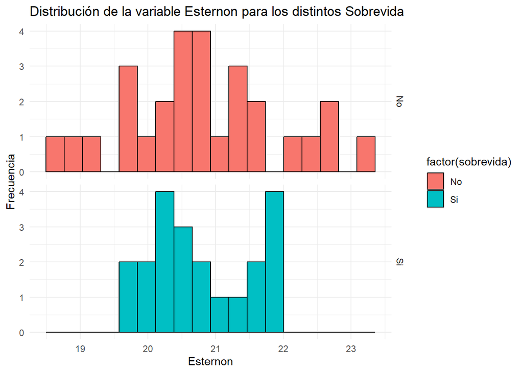

```r
ggplot(gorriones, aes(x=esternon)) +
 geom_histogram(binwidth = 0.27, aes(x = esternon, fill = factor(sobrevida)), color = 'black') +
  facet_grid(sobrevida~., scales = 'free') +
  xlab("Esternon") +
  ylab("Frecuencia") +
  ggtitle("Distribución de la variable Esternon para los distintos Sobrevida") +
  theme_minimal()
```

De manera complementaria se realizaron diagramas de dispersión usando las funciones de densidad.

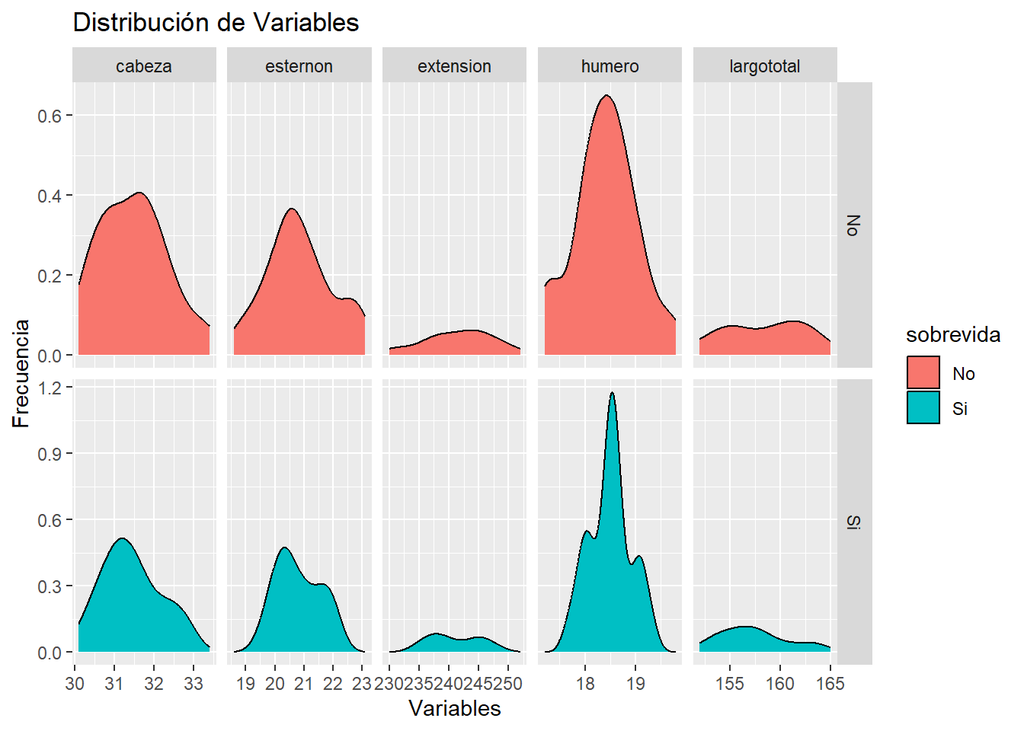

```r
gorriones %>% select(-c(pajaro)) %>%
  pivot_longer(names_to ="Variable", values_to = 'Valor', cols = 1:5) %>%
  ggplot(aes(x=Valor, fill = sobrevida)) +
  geom_density() +
  facet_grid(sobrevida~Variable, scales = 'free') +
  xlab("Variables") +
  ylab("Frecuencia") +
  ggtitle("Distribución de Variables")
```

Finalmente para que las variables puedan ser comparadas entre sí se realizó una tranformación a puntuaciones Z y se las graficó en la misma escala.

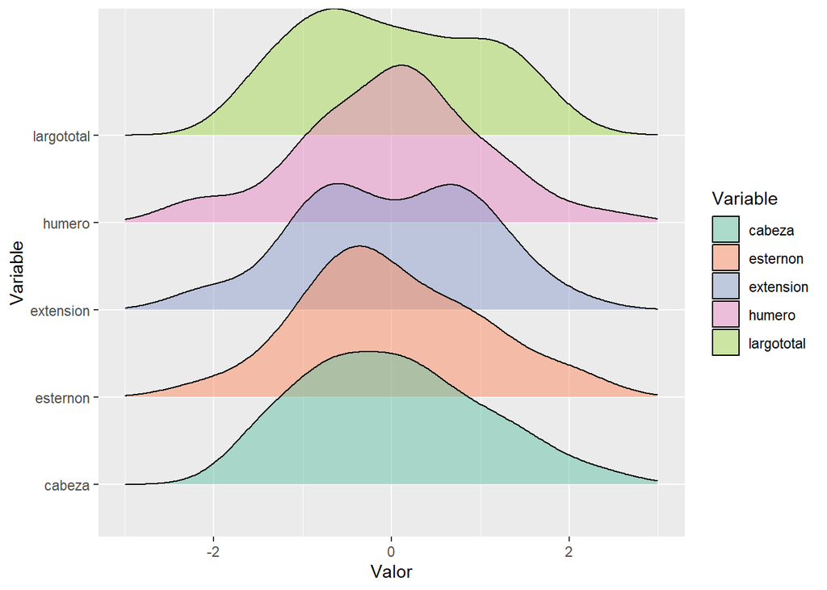

```r
gorriones %>% select(-c(pajaro)) %>%
  mutate_if(is.numeric, ~scale(.)) %>%
  pivot_longer(names_to ="Variable", values_to = 'Valor', cols = 1:5) %>%
  ggplot(aes(x=Valor, y= Variable, fill=Variable))+
  geom_density_ridges(alpha=0.5)+
  scale_fill_brewer(palette = "Set2")+
  xlim(-3,3)
```

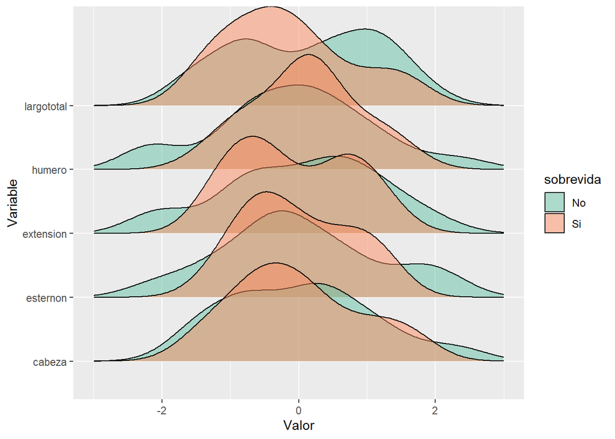

```r
gorriones %>% select(-c(pajaro)) %>%
  mutate_if(is.numeric, ~scale(.)) %>%
  pivot_longer(names_to ="Variable", values_to = 'Valor', cols = 1:5) %>%
  ggplot(aes(x=Valor, y= Variable, fill=sobrevida))+
  geom_density_ridges(alpha=0.5)+
  scale_fill_brewer(palette = "Set2")+
  xlim(-3,3)
```

### (d) Realizar un boxplot comparativo para cada una de estas variables particionando por el grupo definido por la supervivencia. ¿Le parece que alguna de estas variables está relacionada con la supervivencia, es decir que toma valores muy distintos en ambos grupos? Analizar en todos los casos la presencia de outliers.

Para poder responder la pregunta se realiza un grafico transformando los valores y comparando todas las variables.

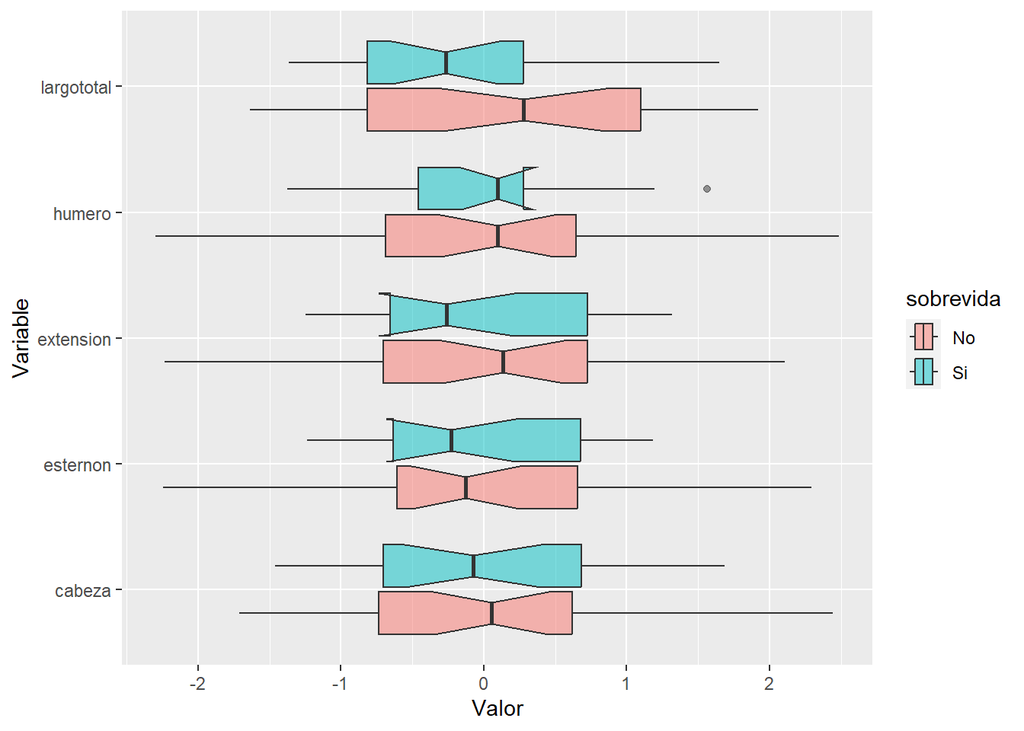

```r
gorriones %>% select(largototal,
                    extension,
                    cabeza,
                    humero,
                    esternon,
                    sobrevida) %>%
  mutate_if(is.numeric, ~scale(.)) %>%
  pivot_longer(names_to ="Variable", values_to = 'Valor', cols = 1:5) %>%
  ggplot(aes(x=Valor, y= Variable, fill = sobrevida))+
  geom_boxplot(alpha=0.5, notch=TRUE)
```

Usando la información del boxplot no es posible diferenciar si las variables afectan a la sobrevida. Existen diferencias en las medianas para cada grupo, sin embargo las diferencias no parecen ser significativas.

### (e) Construir gráficos bivariados para las todas las variables, particionan- do por el grupo de supervivencia (un color para cada grupo). ¿Observa alguna regularidad que pueda explicar la supervivencia?

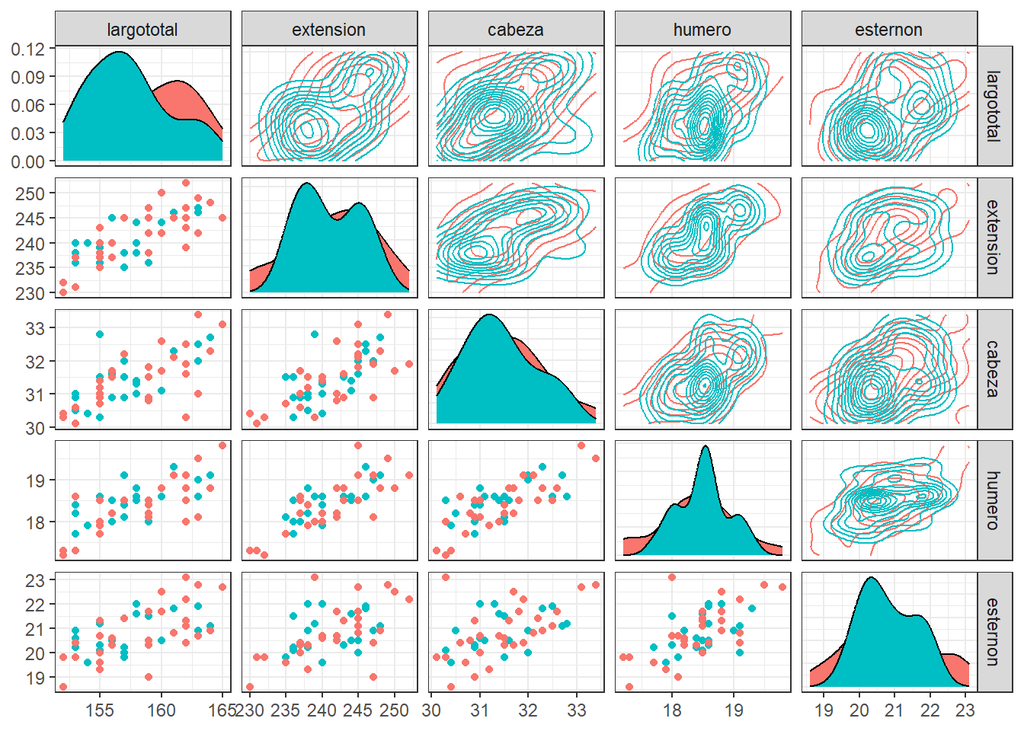

```r
gorr=gorriones%>%select(largototal:esternon)
sobrev=factor(gorriones$sobrevida)
ggpairs(gorr, aes(color=sobrev),
        upper = list(continuous = "density", combo = "box_no_facet"),
        lower = list(continuous = "points" , combo ="dot_no_facet"))+
  theme_bw()
```

No se observan graficamente posibilidades de segregar los datos a partir de la combinacion de 2 variables.

###(f) Construir la matriz de diagramas de dispersión. ¿Considera que algún par de estas medidas están relacionadas? Estudiar si la asociación de algunas de estas medidas es diferente en alguno de los grupos.

```r
library("ggcorrplot")
#http://www.sthda.com/english/wiki/ggcorrplot-visualization-of-a-correlation-matrix-using-ggplot2
```

```r
cor(gorriones[,2:6])
```

```
##            largototal extension    cabeza    humero  esternon
## largototal  1.0000000 0.7349642 0.6618119 0.6796721 0.6051247
## extension   0.7349642 1.0000000 0.6737411 0.7694737 0.5290138
## cabeza      0.6618119 0.6737411 1.0000000 0.7560176 0.5262701
## humero      0.6796721 0.7694737 0.7560176 1.0000000 0.6071711
## esternon    0.6051247 0.5290138 0.5262701 0.6071711 1.0000000
```

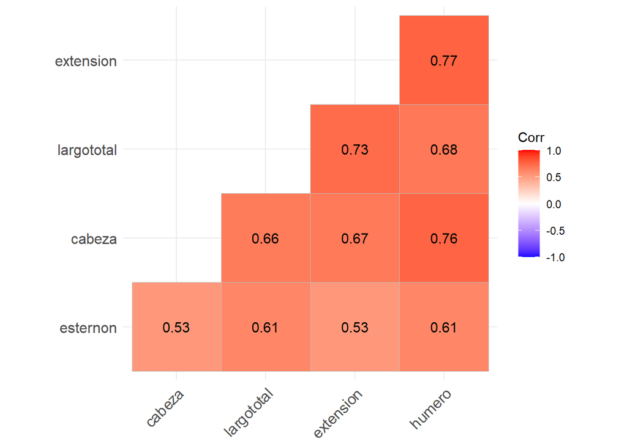

```r
ggcorrplot(cor(gorriones[,2:6]), hc.order = TRUE, type = "lower",
   lab = TRUE)
```

```r
library(patchwork)
```

```r
a = ggcorrplot(cor(gorriones[gorriones$sobrevida=='Si',2:6]), hc.order = TRUE, type = "lower",
   lab = TRUE)+ ggtitle("Sobrevida Si")
```

```r
b = ggcorrplot(cor(gorriones[gorriones$sobrevida=='No',2:6]), hc.order = TRUE, type = "lower",
   lab = TRUE)+ggtitle("Sobrevida No")
```

Estudiar si la asociación de algunas de estas medidas es diferente en alguno de los grupos. Si hay diferencias en las correlaciones para cada grupo.

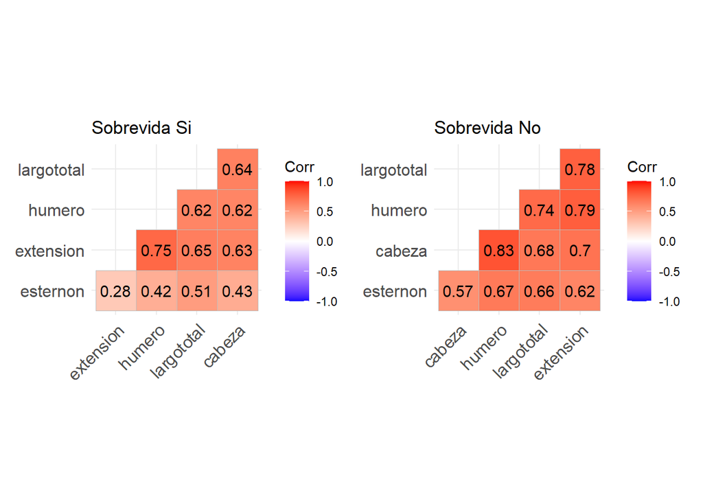

```r
a+b
```

```r
#install.packages("corrr")
```

```r
library(corrr)
```

```
## Correlation computed with
## • Method: 'pearson'
## • Missing treated using: 'pairwise.complete.obs'
```

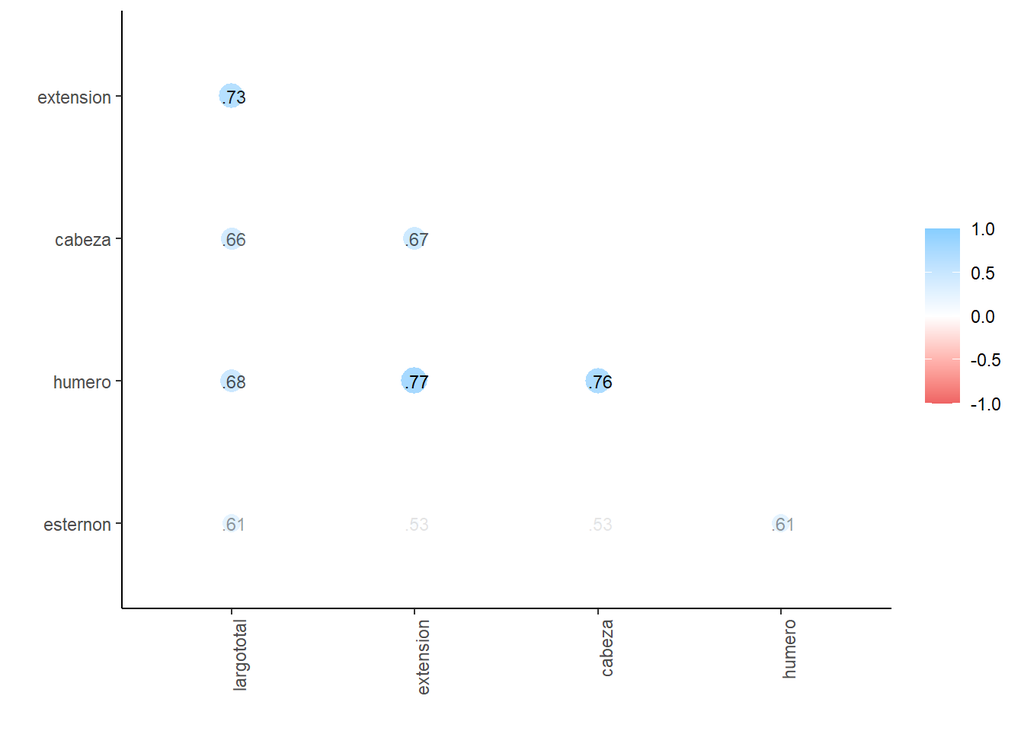

```r
gorriones %>%
  select(-c(pajaro, sobrevida)) %>%
  correlate() %>%
  shave() %>%
  rplot(print_cor=TRUE) +
  theme(axis.text.x=element_text(angle = 90, hjust=1))
```

## Ejercicio 4

```r
razaperros <- read_excel("razaperros.xls")
```

1. Realizar un gráfico de estrellas por raza (utilizando las variables tamaño, peso, velocidad, inteligencia y afectividad.

```r
razaperros
```

```
## # A tibble: 26 × 8
##    raza      tamaño  peso velocidad inteligencia afectividad agresividad funcion
##    <chr>      <dbl> <dbl>     <dbl>        <dbl>       <dbl>       <dbl> <chr>
##  1 basset         1     1         1            1           1           3 caza
##  2 beauceron      3     2         3            2           3           3 utilit…
##  3 boxer          2     2         2            2           3           3 compañ…
##  4 buldog         1     1         1            2           3           1 compañ…
##  5 bulmastif      3     3         1            3           1           3 utilit…
##  6 caniche        1     1         2            3           3           1 compañ…
##  7 chihuahua      1     1         1            1           3           1 compañ…
##  8 cocker         2     1         1            2           3           3 compañ…
##  9 collie         3     2         3            2           3           1 compañ…
## 10 dalmata        2     2         2            2           3           1 compañ…
## # ℹ 16 more rows
```

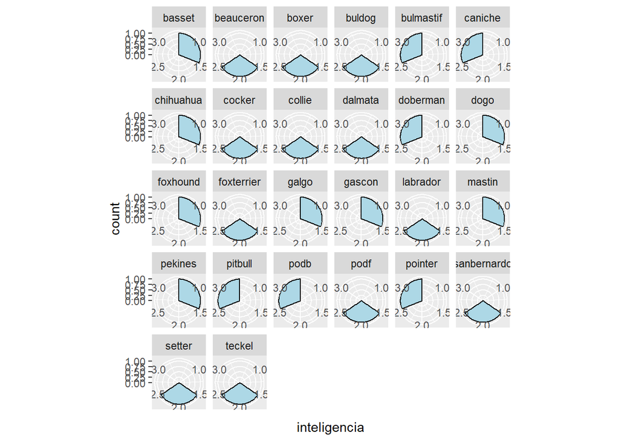

```r
ggplot(data = razaperros, aes(x = inteligencia)) + geom_bar(fill = "lightblue", colour = "black")+ coord_polar() +
  facet_wrap(~raza)
```

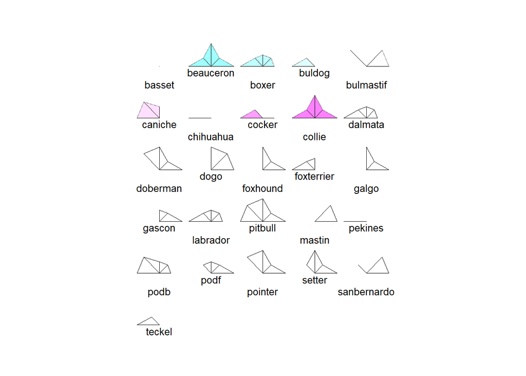

```r
stars(razaperros[,2:6], full=F, cex=0.8, flip.labels = T, labels = razaperros$raza, col.stars = cm.colors(9))
```

```r
library(fmsb)
```

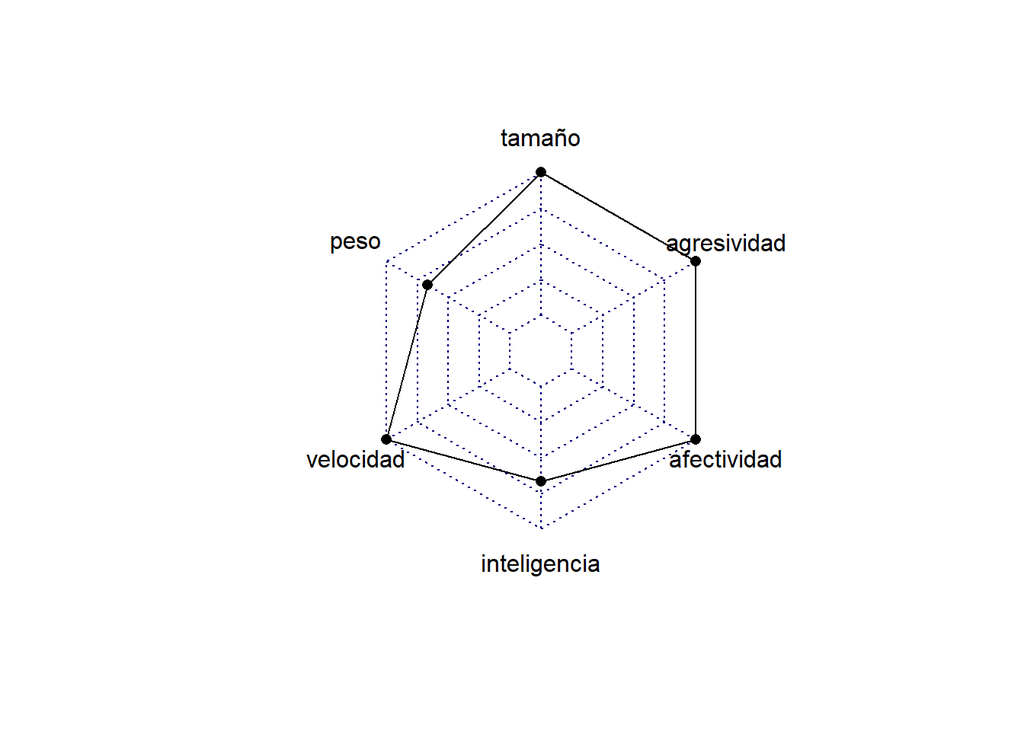

```r
#raza
raza <-razaperros[2,2:7]
data <- rbind(rep(3,6) , rep(0,6) , raza)

# Check your data, it has to look like this!
# head(data)

# The default radar chart
radarchart(data)
```